# carry_model

```python
import pandas as pd
import numpy as np
import math
from statsmodels.tsa.stattools import acf, pacf, adfuller, coint
from statsmodels.tsa.api import VAR
from statsmodels.tsa.vector_ar.vecm import coint_johansen, VECM, VECMResults, CointRankResults, select_coint_rank
import statsmodels.api as sm
from scipy.stats import skew, kurtosis
from arch.unitroot import engle_granger
import matplotlib.pyplot as plt
from dateutil.relativedelta import relativedelta
from IPython.display import Markdown, Latex
```

1. Data
   - Descriptive statistics
   - Graphs
   - Auto-Correlation coefficients
2. Statistical Tests
   - Augmented Dickey-Fuller unit root tests
   - Ordinary Leasr Square Regression
   - Error Correction Models
     - Engle Granger Test and Johansen Test
     - Results for the B&K Regression Model
     - Results for the Vector Error Correction Model
       - One Cointegrating Vector
       - Three Cointegrating Vector
3. Comparison of model prediction

```python
raw_data = pd.read_excel('D:/Xin/Program/carry_model/CU.xlsx')

print(raw_data.head())
print(raw_data.tail())
```

```
        date  cash_price  futures_price  inventory  interest_rate
0 2009-12-31       59125          60020     597640         1.5066
1 2010-01-04       59975          60030     597715         1.5113
2 2010-01-05       59950          60590     600665         1.5213
3 2010-01-06       61025          61630     602715         1.5355
4 2010-01-07       61025          61170     602790         1.5610
           date  cash_price  futures_price  inventory  interest_rate
2547 2020-06-29       48770          48380     321646         2.1144
2548 2020-06-30       48770          48790     316571         2.1750
2549 2020-07-01       49450          49350     313296         2.1276
2550 2020-07-02       49460          49410     310671         2.0976
2551 2020-07-03       49260          48900     320693         2.0976
```

```python
raw_data.loc[:, 'interest_rate_CCR'] = raw_data.loc[:, 'interest_rate'].apply(lambda x: 100 * math.log(1 + x / 100))
raw_data.loc[:, 'diff_interest_rate_CCR'] = raw_data.loc[:, 'interest_rate_CCR'].diff()

raw_data.loc[:, 'log_inventory'] = raw_data.loc[:, 'inventory'].apply(lambda x: math.log(x))
raw_data.loc[:, 'diff_log_inventory'] = raw_data.loc[:, 'log_inventory'].diff()

raw_data.loc[:, 'log_cash_price'] = raw_data.loc[:, 'cash_price'].apply(lambda x: math.log(x))
raw_data.loc[:, 'diff_log_cash_price'] = raw_data.loc[:, 'log_cash_price'].diff()

raw_data.loc[:, 'log_futures_price'] = raw_data.loc[:, 'futures_price'].apply(lambda x: math.log(x))
raw_data.loc[:, 'diff_log_futures_price'] = raw_data.loc[:, 'log_futures_price'].diff()

raw_data.loc[:, 'std_return_20d'] = raw_data.loc[:, 'diff_log_cash_price'].rolling(20).std()
raw_data.loc[:, 'diff_std_return_20d'] = raw_data.loc[:, 'std_return_20d'].diff()

raw_data.loc[:, 'autocorr_return_20d'] = raw_data.loc[:, 'diff_log_cash_price'].rolling(20).apply(lambda x: x.autocorr(lag=1), raw=False)
raw_data.loc[:, 'diff_autocorr_return_20d'] = raw_data.loc[:, 'autocorr_return_20d'].diff()

raw_data.loc[:, 'log_futures_less_log_cash'] = raw_data.loc[:, 'log_futures_price'] - raw_data.loc[:, 'log_cash_price']
```

# 1. Data

```python
def des_stat(x, level):
    sub_df = pd.DataFrame(data={'Mean': [np.mean(x)], 'S.D.': [np.std(x)], 'Skewness': [skew(x)], 'Kurtosis': [kurtosis(x)]}, index=[level])

    return sub_df

table_1 = pd.DataFrame()
for level in ['interest_rate', 'interest_rate_CCR', 'inventory', 'log_inventory', 'cash_price', 'log_cash_price', 'futures_price', 'log_futures_price', 'std_return_20d', 'autocorr_return_20d']:
    x = raw_data.loc[:, level].fillna(0).values
    sub_df = des_stat(x, level)
    table_1 = table_1.append(sub_df)
```

## 1.1 Descriptive statistics:

```
see Table 1 for daily observations of 'SHFE CU'
```

```python
print('Table 1: Descriptive statistics')
print(table_1)
```

```
Table 1: Descriptive statistics
                              Mean           S.D.  Skewness  Kurtosis
interest_rate             2.791027       0.622591 -0.097801 -0.475459
interest_rate_CCR         2.750953       0.605889 -0.111594 -0.467892
inventory            476544.208856  130387.103268  0.429321  0.320887
log_inventory            13.035425       0.284414 -0.419533  0.123282
cash_price            50830.474922    8515.321380  0.425359  0.166710
log_cash_price           10.822308       0.167278 -0.057445 -0.101740
futures_price         50742.644984    8622.675509  0.478858  0.197364
log_futures_price        10.820259       0.168941 -0.004874 -0.116923
std_return_20d            0.009389       0.004651  1.545051  3.170396
autocorr_return_20d      -0.031739       0.185260  0.019196  0.119663
```

## 1.2 Graphs:

```
see Fig1 - Fig5
```

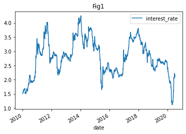

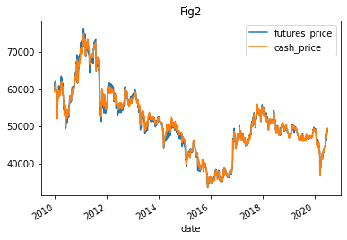

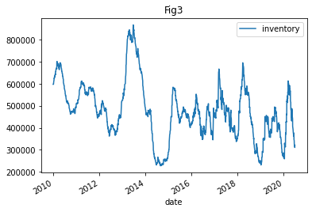

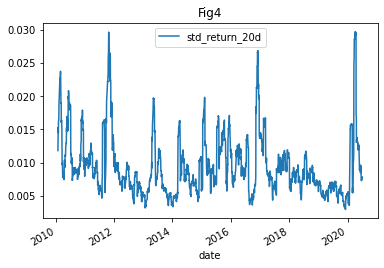

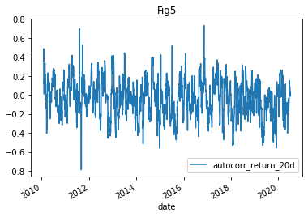

```python
raw_data.plot(x='date', y=['interest_rate'], title='Fig1')
raw_data.plot(x='date', y=['futures_price', 'cash_price'], title='Fig2')
raw_data.plot(x='date', y=['inventory'], title='Fig3')
raw_data.plot(x='date', y=['std_return_20d'], title='Fig4')
raw_data.plot(x='date', y=['autocorr_return_20d'], title='Fig5')
```

```python
def auto_corr(x, level):
    r1 = x.autocorr(lag=1)
    r2 = x.autocorr(lag=2)
    r3 = x.autocorr(lag=3)
    r4 = x.autocorr(lag=4)
    r5 = x.autocorr(lag=5)
    r12 = x.autocorr(lag=12)
    r24 = x.autocorr(lag=24)
    sub_df = pd.DataFrame(data= {'r1': [r1], 'r2': [r2], 'r3': [r3], 'r4': [r4], 'r5': [r5], 'r12': [r12], 'r24': [r24], }, index=[level])

    return sub_df

table_2 = pd.DataFrame()
for level in ['interest_rate_CCR',  'diff_interest_rate_CCR', 'log_inventory', 'diff_log_inventory', 'log_cash_price', 'diff_log_cash_price', 'log_futures_price', 'diff_log_futures_price', 'std_return_20d', 'diff_std_return_20d', 'autocorr_return_20d','diff_autocorr_return_20d']:
    x = raw_data.loc[:, level].fillna(0)
    sub_df = auto_corr(x, level)
    table_2 = table_2.append(sub_df)
```

## 1.3 Auto-Correlation coefficients:

```
reported in Table 2 for each of the variables
```

```python
print('Table 2: Auto correlation over levels and change in levels')
table_2
```

```
Table 2: Auto correlation over levels and change in levels
```

|  | r1 | r2 | r3 | r4 | r5 | r12 | r24 |
| --- | --- | --- | --- | --- | --- | --- | --- |
| interest_rate_CCR | 0.998276 | 0.995455 | 0.992012 | 0.988212 | 0.984175 | 0.951506 | 0.887164 |
| diff_interest_rate_CCR | 0.317088 | 0.178536 | 0.102148 | 0.065858 | 0.056651 | 0.029749 | 0.031798 |
| log_inventory | 0.997658 | 0.994661 | 0.991294 | 0.987629 | 0.983823 | 0.945597 | 0.852569 |
| diff_log_inventory | 0.140045 | 0.078151 | 0.062502 | 0.029146 | 0.255173 | 0.027547 | 0.003220 |
| log_cash_price | 0.998014 | 0.995870 | 0.993591 | 0.991302 | 0.988965 | 0.972860 | 0.948029 |
| diff_log_cash_price | 0.040051 | 0.033799 | 0.003523 | 0.012139 | -0.001419 | -0.000698 | 0.002027 |
| log_futures_price | 0.997335 | 0.994956 | 0.992413 | 0.989818 | 0.987303 | 0.970127 | 0.943270 |
| diff_log_futures_price | -0.053495 | 0.030344 | 0.010367 | -0.015738 | 0.006972 | -0.012450 | -0.005663 |
| std_return_20d | 0.977860 | 0.953202 | 0.924630 | 0.894432 | 0.862553 | 0.615135 | 0.290536 |
| diff_std_return_20d | 0.045157 | 0.089003 | 0.041951 | 0.038771 | -0.005310 | 0.016655 | -0.007233 |
| autocorr_return_20d | 0.885263 | 0.803311 | 0.727433 | 0.668979 | 0.600099 | 0.252414 | -0.028156 |
| diff_autocorr_return_20d | -0.146104 | -0.020382 | -0.076596 | 0.046093 | -0.027800 | 0.028194 | -0.022681 |

# 2. Statistical Tests

```python
var_dic = {'interest rate (C.C.R.)': ['interest_rate_CCR',  'diff_interest_rate_CCR'], 'natural log of the inventory': ['log_inventory', 'diff_log_inventory'], 'natural log of the cash price': ['log_cash_price', 'diff_log_cash_price'], 'natural log of futures price': ['log_futures_price', 'diff_log_futures_price'], 'cash price return std': [ 'std_return_20d', 'diff_std_return_20d'], 'cash price return 1-order auto-corr coef': ['autocorr_return_20d','diff_autocorr_return_20d']}

table_3 = pd.DataFrame()

for key in var_dic:
    key_list = var_dic[key]
    levels_1_lag = round(adfuller(x=raw_data.loc[:, key_list[0]].fillna(0).values, maxlag=1, regression='ct')[0], 2)
    levels_2_lag = round(adfuller(x=raw_data.loc[:, key_list[0]].fillna(0).values, maxlag=2, regression='ct')[0], 2)
    levels_4_lag = round(adfuller(x=raw_data.loc[:, key_list[0]].fillna(0).values, maxlag=4, regression='ct')[0], 2)
    change_in_levels_1_lag = round(adfuller(x=raw_data.loc[:, key_list[1]].fillna(0).values, maxlag=1, regression='ct')[0], 2)
    change_in_levels_2_lag = round(adfuller(x=raw_data.loc[:, key_list[1]].fillna(0).values, maxlag=2, regression='ct')[0], 2)
    change_in_levels_4_lag = round(adfuller(x=raw_data.loc[:, key_list[1]].fillna(0).values, maxlag=4, regression='ct')[0], 2)

    sub_df = pd.DataFrame(data=[[levels_1_lag, levels_2_lag, levels_4_lag, change_in_levels_1_lag, change_in_levels_2_lag, change_in_levels_4_lag]], index=[key])

    table_3 = table_3.append(sub_df)

columns=[('Levels', '1 lag'), ('Levels', '2 lags'), ('Levels', '4 lags'), ('Change in Levels', '1 lag'), ('Change in Levels', '2 lags'), ('Change in Levels', '4 lags')]
table_3.columns = pd.MultiIndex.from_tuples(columns)
```

## 2.1 Augmented Dickey-Fuller unit root tests:

```
including both intercept and trend, reported in Table 3
```

```python
print('Table 3: unit root test----augumented Dickey-Fuller test statistic')
table_3
```

```
Table 3: unit root test----augumented Dickey-Fuller test statistic
```

|  | Levels 1 lag | Levels 2 lags | Levels 4 lags | Change in Levels 1 lag | Change in Levels 2 lags | Change in Levels 4 lags |
| --- | --- | --- | --- | --- | --- | --- |
| interest rate (C.C.R.) | -2.49 | -2.63 | -2.63 | -27.06 | -27.06 | -27.06 |
| natural log of the inventory | -2.12 | -2.25 | -2.36 | -31.15 | -25.33 | -15.85 |
| natural log of the cash price | -1.91 | -1.98 | -1.98 | -33.86 | -33.86 | -33.86 |
| natural log of futures price | -2.03 | -2.10 | -2.10 | -53.25 | -53.25 | -53.25 |
| cash price return std | -5.96 | -6.50 | -6.96 | -31.95 | -26.06 | -22.50 |
| cash price return 1-order auto-corr coef | -11.19 | -11.19 | -10.61 | -39.86 | -34.15 | -34.15 |

## 2.2 Ordinary Least Square Regression:

```
The results of regressions based on Eqn.(1) and (2) are reported in Table 4
```

$$ DP_t = a_0 + a_1 DF_{t|t-1} + e_t \tag{1} $$$$ DP_t = b_0 + b_1 (F_{t|t-1} - P_{t-1}) + e_t \tag{2} $$

```python
y_1 = raw_data.loc[:, 'diff_log_cash_price'].values[2:]
X_1 = raw_data.loc[:, 'diff_log_futures_price'].shift(1).values[2:]
X_1 = sm.add_constant(X_1)
model_1 = sm.OLS(y_1, X_1)
results_1 = model_1.fit()
print('Table 4: OLS Regression' + '\n' + 'Panel A: Regression of cash price change on the lagged futures price change')
print(results_1.summary(xname=['intercept', 'diff_log_futures_price'], yname='diff_log_cash_price'))
```

```
Table 4: OLS Regression
Panel A: Regression of cash price change on the lagged futures price change
                             OLS Regression Results
===============================================================================
Dep. Variable:     diff_log_cash_price   R-squared:                       0.055
Model:                             OLS   Adj. R-squared:                  0.055
Method:                  Least Squares   F-statistic:                     147.9
Date:                 Fri, 04 Dec 2020   Prob (F-statistic):           3.99e-33
Time:                         10:25:52   Log-Likelihood:                 8062.4
No. Observations:                 2550   AIC:                        -1.612e+04
Df Residuals:                     2548   BIC:                        -1.611e+04
Df Model:                            1
Covariance Type:             nonrobust
==========================================================================================
                             coef    std err          t      P>|t|      [0.025      0.975]
------------------------------------------------------------------------------------------
intercept              -6.191e-05      0.000     -0.305      0.760      -0.000       0.000
diff_log_futures_price     0.2002      0.016     12.163      0.000       0.168       0.232
==============================================================================
Omnibus:                      480.722   Durbin-Watson:                   2.308
Prob(Omnibus):                  0.000   Jarque-Bera (JB):             6847.825
Skew:                          -0.462   Prob(JB):                         0.00
Kurtosis:                      10.975   Cond. No.                         81.1
==============================================================================

Notes:
[1] Standard Errors assume that the covariance matrix of the errors is correctly specified.
```

```python
y_2 = raw_data.loc[:, 'diff_log_cash_price'].values[2:]
X_2 = raw_data.loc[:, 'log_futures_less_log_cash'].shift(1).values[2:]
X_2 = sm.add_constant(X_2)
model_2 = sm.OLS(y_2, X_2)
results_2 = model_2.fit()
print('Panel B: Regression of cash price change on lagged difference between futures price and cash price')
print(results_2.summary(xname=['intercept', 'log_futures_less_log_cash'], yname='diff_log_cash_price'))
```

```
Panel B: Regression of cash price change on lagged difference between futures price and cash price
                             OLS Regression Results
===============================================================================
Dep. Variable:     diff_log_cash_price   R-squared:                       0.046
Model:                             OLS   Adj. R-squared:                  0.046
Method:                  Least Squares   F-statistic:                     124.0
Date:                 Fri, 04 Dec 2020   Prob (F-statistic):           3.79e-28
Time:                         10:25:52   Log-Likelihood:                 8051.0
No. Observations:                 2550   AIC:                        -1.610e+04
Df Residuals:                     2548   BIC:                        -1.609e+04
Df Model:                            1
Covariance Type:             nonrobust
=============================================================================================
                                coef    std err          t      P>|t|      [0.025      0.975]
---------------------------------------------------------------------------------------------
intercept                     0.0003      0.000      1.661      0.097   -6.22e-05       0.001
log_futures_less_log_cash     0.2053      0.018     11.134      0.000       0.169       0.242
==============================================================================
Omnibus:                      520.165   Durbin-Watson:                   1.887
Prob(Omnibus):                  0.000   Jarque-Bera (JB):             8518.788
Skew:                          -0.498   Prob(JB):                         0.00
Kurtosis:                      11.899   Cond. No.                         90.4
==============================================================================

Notes:
[1] Standard Errors assume that the covariance matrix of the errors is correctly specified.
```

#### Remark：

```
These results of regressions based on Eqs. (1) and (2) offer a base case for comparison as they replicate the early tests of the ability of futures prices to predict cash prices. Both slope parameters are significantly different from zero.

Before error correction models can be estimated, we have to identify the number of cointegrating vectors that exists between the variables, future prices, cash prices, interest rate, inventory, cash price return standard deviation and cash price return first order auto-correlation coefficient.
```

## 2.3 Error Correction Models:

As is known in the thesis, the Brenner and Kroner (1995) correction model can be written as:

$$ DP_t = g_0 + g_1 DF_{t|t-1} + g_2 Dr_{t|t-1} + g_3 DI_{t-1} + g_4 D\sigma_{t-1} + g_5 D\rho(1)_{t-1} + g_6 ECT_{t-2} + e_t \tag{6} $$

The error correction term, $ECT_{t-2}$ is the residual, $e_{t-1}$ from the regression:

$$ P_{t-1} = h_0 + h_1 F_{t-1|t-2} + h_2 r_{t-1|t-2} + h_3I_{t-2} + h_4 \sigma_{t-2} + h_5\rho(1)_{t-2} + e_{t-1} \tag{7} $$

with $g_i$ and $h_i$ as estimated parameters. Rearranging Eqs.(6) provides the more traditional form of the error correction model

$$ DP_t = i_0 + i_1 DF_{t|t-1} + i_2 DP_{t|t-1} + i_3 Dr_{t|t-1} + i_4 I_{t-1} + i_5 D\sigma_{t-1} + i_6 D\rho(1)_{t-1} + i_7 ECT_{t-2}^{*} + e_t \tag{8} $$

The error correction term, $ECT^{*}_{t-2}$ or cost of carry pricing discrepancy, is the residual, $e_{t-1}$ from the regression: $$ P_{t-2} = j_0 + j_1 F_{t-1|t-2} + j_2 r_{t-1|t-2} + j_3I_{t-2} + j_4 \sigma_{t-2} + j_5\rho(1)_{t-2} + e_{t-1} \tag{9} $$ with $i_i$ and $j_i$ as estimated parameters.

### 2.3.1 Engle Granger Test and Johansen Test:

```
Augmented Dickey-Fuller tests are reported for the Engle-Granger cointegration test with statistics for three lag choices, 1 lag, 2lags, 4lags, see Table 5, Panel A. In all cases, the null of no cointegration is rejected in favor of the alternative of cointegration, though this test provides little indication of whether there is more than cointegrating vector.

Panel B of Table 5 identifies THREE cointegrating vectors in the system using either the Trace statistic or the Maximal value statistic.
```

```python
data = raw_data.dropna(axis=0)

y_log_P = data.loc[:, 'log_cash_price'].values[1:]
X_BK = data.loc[:, ['log_futures_price', 'interest_rate', 'log_inventory', 'std_return_20d', 'autocorr_return_20d']].shift(periods=1, axis=0).values[1:]
X_Std = data.loc[:, ['log_futures_price', 'interest_rate', 'log_inventory', 'std_return_20d', 'autocorr_return_20d']].values[1:]


table_5_Panel_A = pd.DataFrame()
coin_vec_dic = {}
for key, value in {'BnK ECT': X_BK, 'Std ECT': X_Std}.items():
    res_1_lag = engle_granger(y_log_P, value, trend='c', lags=1)
    t_stat_1_lag = res_1_lag.stat
    coin_vec_dic[key] = res_1_lag.cointegrating_vector

    res_2_lags = engle_granger(y_log_P, value, trend='c', lags=2)
    t_stat_2_lags = res_2_lags.stat

    res_4_lags = engle_granger(y_log_P, value, trend='c', lags=4)
    t_stat_4_lags = res_4_lags.stat

    sub_df = pd.DataFrame(data=[[t_stat_1_lag, t_stat_2_lags, t_stat_4_lags]], index=[key])
    table_5_Panel_A = pd.concat([table_5_Panel_A, sub_df], axis=0)
```

```python
data_test_johansen = pd.concat([pd.DataFrame(data=y_log_P, columns=['log_cash_price']), pd.DataFrame(data=X_BK, columns=['log_futures_price', 'interest_rate_CCR', 'log_inventory', 'std_return_20d', 'autocorr_return_20d'])], axis=1)

johansen_res = coint_johansen(data_test_johansen, det_order=0, k_ar_diff=1)
table_5_Panel_B = pd.DataFrame(columns=['Trace_statistic', 'CV_Trace_90pct', 'CV_Trace_95pct', 'CV_Trace_99pct', 'MaxEig_statistic', 'CV_MaxEig_90pct', 'CV_MaxEig_95pct', 'CV_MaxEig_99pct'], index=['rank = 0', 'rank <= 1', 'rank <= 2', 'rank <= 3', 'rank <= 4', 'rank <= 5'])
table_5_Panel_B.loc[:, 'Trace_statistic'] = johansen_res.lr1
table_5_Panel_B.loc[:, 'MaxEig_statistic'] = johansen_res.lr2
table_5_Panel_B.loc[:, ['CV_Trace_90pct', 'CV_Trace_95pct', 'CV_Trace_99pct']] = johansen_res.cvt
table_5_Panel_B.loc[:, ['CV_MaxEig_90pct', 'CV_MaxEig_95pct', 'CV_MaxEig_99pct']] = johansen_res.cvm
```

```python
print('Table 5: Test for cointegration' + '\n')
print('Panel A: Engle and Granger test using the augumented Dickey-Fuller Test')
table_5_Panel_A.columns = ['1 lag', '2 lags', '4 lags']
print(table_5_Panel_A)
print('\n')
print('Panel B: Johansen test for cointegration vectors')
print(table_5_Panel_B)

vec_rank1 = select_coint_rank(data_test_johansen, det_order=0, k_ar_diff=1, method='trace', signif=0.05)
print(vec_rank1.summary())
vec_rank2 = select_coint_rank(data_test_johansen, det_order=0, k_ar_diff=1, method='maxeig', signif=0.05)
print(vec_rank2.summary())
```

```
Table 5: Test for cointegration

Panel A: Engle and Granger test using the augumented Dickey-Fuller Test
             1 lag     2 lags     4 lags
BnK ECT -19.490954 -14.365833 -10.108119
Std ECT -12.857084 -10.001291  -7.557129


Panel B: Johansen test for cointegration vectors
           Trace_statistic  CV_Trace_90pct  CV_Trace_95pct  CV_Trace_99pct  \
rank = 0        462.628104         91.1090         95.7542        104.9637
rank <= 1       189.032469         65.8202         69.8189         77.8202
rank <= 2        61.053116         44.4929         47.8545         54.6815
rank <= 3        20.478250         27.0669         29.7961         35.4628
rank <= 4         9.691538         13.4294         15.4943         19.9349
rank <= 5         3.627629          2.7055          3.8415          6.6349

           MaxEig_statistic  CV_MaxEig_90pct  CV_MaxEig_95pct  CV_MaxEig_99pct
rank = 0         273.595634          37.2786          40.0763          45.8662
rank <= 1        127.979354          31.2379          33.8777          39.3693
rank <= 2         40.574866          25.1236          27.5858          32.7172
rank <= 3         10.786713          18.8928          21.1314          25.8650
rank <= 4          6.063908          12.2971          14.2639          18.5200
rank <= 5          3.627629           2.7055           3.8415           6.6349
Johansen cointegration test using trace test statistic with 5% significance level
=====================================
r_0 r_1 test statistic critical value
-------------------------------------
  0   6          462.6          95.75
  1   6          189.0          69.82
  2   6          61.05          47.85
  3   6          20.48          29.80
-------------------------------------
Johansen cointegration test using maximum eigenvalue test statistic with 5% significance level
=====================================
r_0 r_1 test statistic critical value
-------------------------------------
  0   1          273.6          40.08
  1   2          128.0          33.88
  2   3          40.57          27.59
  3   4          10.79          21.13
-------------------------------------
```

#### Remark(a):

```
Statistically significant at the 5% level of significance with critical value at the 5% level of -4.71. Augmented Dickey Fuller tests are conducted on the residuals from the Brenner and Kroner model(B&K ECT), estimated using OLS:
```

```python
para = -coin_vec_dic['BnK ECT']
Markdown("$P_t = %f + %f F_{t|t-1} + %f r_{t|t-1}+ %f I_{t|t-1} + %f \sigma_{t-1} + %f p(1)_{t-1} + e_t$"%(para[-1], para[1], para[2], para[3], para[4], para[5]))
```

$P_t = 0.223686 + 0.986308 F_{t|t-1} + 0.003813 r_{t|t-1}+ -0.006752 I_{t|t-1} + 0.417978 \sigma_{t-1} + 0.004778 p(1)_{t-1} + e_t$

```
and the standard error correction model (std ECT), estimated using OLS:
```

```python
para = -coin_vec_dic['Std ECT']
Markdown("$P_t = %f + %f F_{t+1|t} + %f r_{t+1|t}+ %f I_{t+1|t} + %f \sigma_{t} + %f p(1)_{t} + e_t$"%(para[-1], para[1] , para[2], para[3], para[4], para[5]))
```

$P_t = 0.208892 + 0.986720 F_{t+1|t} + 0.004069 r_{t+1|t}+ -0.005927 I_{t+1|t} + 0.297561 \sigma_{t} + 0.003271 p(1)_{t} + e_t$

#### Remark(b):

```
The null hypothesis that there are less than or equal to 3 cointegration relations can not be rejected at 10% level of significance, either in trace method or maximal eigenvalue method.
```

```python
# for key in coin_vec_dic:
#     print(key + ': Cointegration vector for 1 lag')
#     print(coin_vec_dic[key].rename({'y': 'log_cash_price', 'x1': 'log_futures_price', 'x2': 'interest_rate', 'x3': 'log_inventory', 'x4': 'std_return_20d', 'x5': 'autocorr_return_20d'}))


# print(johansen_res.eig)
# print(pd.DataFrame(johansen_res.evec)/pd.DataFrame(johansen_res.evec).iloc[0,:])
# co_r0t = johansen_res.r0t
# print(johansen_res.r0t)
# co_rkt = johansen_res.rkt
# print(johansen_res.rkt)
```

### 2.3.2 Results for the B&K Regression Model.

```
First, we perform regression based on eqaution (7), the results are exhibited in Table 6, panel A. Although the slope parameters are significant for all varaibles, it is the spurious regression since the variables are non-stationary. We have to figure out the cointegration relationship in the six variables. Given the residual terms from regression based on equation (7), we do the difference method and add the error terms, to conduct the regression based on equation (6)

The results in panel B generally support the Brenner and Kronner(1995) argument that the costs of carrying the underlying asset have an impact on the cash price and thus on the ability of the current future price to predict cash prices.

While the parameters for the futures price change is positive and statistically significant, the parameters for the change in inventory and th error correction term parameter are statistically significant and negative signed. The parameter estimates are consistent with the cost carry model. The results are also acceptable for interest rate and standard deviation in 10% significance level.
```

```python
# get residuals
y_7 = data.loc[:, 'log_cash_price'].values[1:]
X_7 = data.loc[:, ['log_futures_price', 'interest_rate_CCR', 'log_inventory', 'std_return_20d', 'autocorr_return_20d']].shift(periods=1).values[1:]
X_7 = sm.add_constant(X_7)
model_7 = sm.OLS(y_7, X_7)
results_7 = model_7.fit()
print('Tbale 6: B&K model')
print('Panel A: based on equation (7)')
print(results_7.summary(yname='log_cash_price', xname=['intercept', 'log_futures_price', 'interest_rate_CCR', 'log_inventory', 'std_return_20d', 'autocorr_return_20d']))
residual = results_7.resid
data.loc[:, 'ECT'] = np.append(np.array([0]), residual)
```

```
Tbale 6: B&K model
Panel A: based on equation (7)
                            OLS Regression Results
==============================================================================
Dep. Variable:         log_cash_price   R-squared:                       0.994
Model:                            OLS   Adj. R-squared:                  0.994
Method:                 Least Squares   F-statistic:                 8.376e+04
Date:                Fri, 04 Dec 2020   Prob (F-statistic):               0.00
Time:                        10:25:52   Log-Likelihood:                 7409.3
No. Observations:                2530   AIC:                        -1.481e+04
Df Residuals:                    2524   BIC:                        -1.477e+04
Df Model:                           5
Covariance Type:            nonrobust
=======================================================================================
                          coef    std err          t      P>|t|      [0.025      0.975]
---------------------------------------------------------------------------------------
intercept               0.2235      0.019     12.029      0.000       0.187       0.260
log_futures_price       0.9863      0.002    592.776      0.000       0.983       0.990
interest_rate_CCR       0.0039      0.000      8.416      0.000       0.003       0.005
log_inventory          -0.0067      0.001     -7.004      0.000      -0.009      -0.005
std_return_20d          0.4180      0.059      7.041      0.000       0.302       0.534
autocorr_return_20d     0.0048      0.001      3.423      0.001       0.002       0.008
==============================================================================
Omnibus:                      197.264   Durbin-Watson:                   1.171
Prob(Omnibus):                  0.000   Jarque-Bera (JB):              863.716
Skew:                           0.244   Prob(JB):                    2.80e-188
Kurtosis:                       5.820   Cond. No.                     3.96e+03
==============================================================================

Notes:
[1] Standard Errors assume that the covariance matrix of the errors is correctly specified.
[2] The condition number is large, 3.96e+03. This might indicate that there are
strong multicollinearity or other numerical problems.
```

```python
y_6 = data.loc[:, 'diff_log_cash_price'].values[1:]
X_6 = data.loc[:, ['diff_log_futures_price', 'diff_interest_rate_CCR', 'diff_log_inventory','diff_std_return_20d', 'diff_autocorr_return_20d', 'ECT']].shift(1, axis=0).values[1:, :]
X_6 = sm.add_constant(X_6)
model_6 = sm.OLS(y_6, X_6)
results_6 = model_6.fit()
print('Table 6: B&K model')
print('Panel B: based on equation (6)')
results_6.summary(yname='diff_log_cash_price', xname=['intercept',  'diff_log_futures_price', 'diff_interest_rate_CCR', 'diff_log_inventory','diff_std_return_20d', 'diff_autocorr_return_20d', 'ECT'])
```

```
Table 6: B&K model
Panel B: based on equation (6)
```

OLS Regression Results

| Dep. Variable: | diff_log_cash_price | R-squared: | 0.094 |
| --- | --- | --- | --- |
| Model: | OLS | Adj. R-squared: | 0.092 |
| Method: | Least Squares | F-statistic: | 43.50 |
| Date: | Fri, 04 Dec 2020 | Prob (F-statistic): | 8.44e-51 |
| Time: | 10:25:52 | Log-Likelihood: | 8063.0 |
| No. Observations: | 2530 | AIC: | -1.611e+04 |
| Df Residuals: | 2523 | BIC: | -1.607e+04 |
| Df Model: | 6 |  |  |
| Covariance Type: | nonrobust |  |  |

|  | coef | std err | t | P>\|t\| | [0.025 | 0.975] |
| --- | --- | --- | --- | --- | --- | --- |
| intercept | -3.653e-05 | 0.000 | -0.184 | 0.854 | -0.000 | 0.000 |
| diff_log_futures_price | 0.3282 | 0.021 | 15.335 | 0.000 | 0.286 | 0.370 |
| diff_interest_rate_CCR | 0.0100 | 0.006 | 1.786 | 0.074 | -0.001 | 0.021 |
| diff_log_inventory | -0.0545 | 0.010 | -5.309 | 0.000 | -0.075 | -0.034 |
| diff_std_return_20d | 0.3804 | 0.210 | 1.813 | 0.070 | -0.031 | 0.792 |
| diff_autocorr_return_20d | 0.0036 | 0.002 | 1.582 | 0.114 | -0.001 | 0.008 |
| ECT | -0.1893 | 0.020 | -9.300 | 0.000 | -0.229 | -0.149 |

| Omnibus: | 480.601 | Durbin-Watson: | 2.206 |
| --- | --- | --- | --- |
| Prob(Omnibus): | 0.000 | Jarque-Bera (JB): | 7230.522 |
| Skew: | -0.449 | Prob(JB): | 0.00 |
| Kurtosis: | 11.233 | Cond. No. | 1.05e+03 |

Notes:  
[1] Standard Errors assume that the covariance matrix of the errors is correctly specified.  
[2] The condition number is large, 1.05e+03. This might indicate that there are  
strong multicollinearity or other numerical problems.

### 2.3.3 Results for the Vector Error Correction Model:

```
Table 7 describes the vector error correction model with ONE cointegrating vector(Panel A) and THREE cointegrating vectors(Panel B). The simple one cointegrating vector model constrains the error correction term to the cost of carry relationship.
```

#### 2.3.3.1 One Cointegrating Vector:

```python
data_vecm = data.loc[:, ['diff_log_cash_price', 'diff_log_futures_price', 'diff_interest_rate_CCR', 'diff_log_inventory', 'diff_std_return_20d', 'diff_autocorr_return_20d']]
model = VECM(data_vecm, deterministic='ci', k_ar_diff=1, coint_rank=1)
results = model.fit()
```

```python
coin_vector = pd.concat([pd.DataFrame(results.beta, index=['log_cash_price', 'log_futures_price', 'interest_rate_CCR', 'log_inventory', 'std_return_20d' , 'autocorr_return_20d'], columns=['cointegrating_vector']),
                                      pd.DataFrame(results.det_coef_coint, index=['constant'], columns=['cointegrating_vector'])], axis=0)

gamma = pd.DataFrame(results.gamma)
gamma = gamma.round(3).T
gamma.index = ['L1.diff_log_cash_price', 'L1.diff_log_futures_price', 'L1.diff_interest_rate_CCR', 'L1.diff_log_inventory', 'L1.diff_std_return_20d' , 'L1.diff_autocorr_return_20d']
gamma.columns = ['diff_log_cash_price', 'diff_log_futures_price', 'diff_interest_rate_CCR', 'diff_log_inventory', 'diff_std_return_20d', 'diff_autocorr_return_20d']
alpha = pd.DataFrame(results.alpha)
alpha = alpha.round(3).T
alpha.index = ['Error Correction Term']
alpha.columns = gamma.columns

df = pd.concat([gamma, alpha], axis=0)

tvalues_gamma = pd.DataFrame(results.tvalues_gamma)
tvalues_gamma = tvalues_gamma.round(3).T
tvalues_alpha = pd.DataFrame(results.tvalues_alpha)
tvalues_alpha = tvalues_alpha.round(3).T
tvalues = pd.concat([tvalues_gamma, tvalues_alpha], axis=0)

for i in range(0, 7):
    for j in range(0, 6):
        if np.abs(tvalues.iloc[i, j]) > 1.96:
            df.iloc[i, j] = str(df.iloc[i, j]) + "*" + " ({})".format(tvalues.iloc[i, j])
        else:
            df.iloc[i, j] = str(df.iloc[i, j]) + " ({})".format(tvalues.iloc[i, j])
```

```python
print('Table 7: Cost of carry vector correction models')
print('Panel A: One cointegrating vector')
df
```

```
Table 7: Cost of carry vector correction models
Panel A: One cointegrating vector
```

|  | diff_log_cash_price | diff_log_futures_price | diff_interest_rate_CCR | diff_log_inventory | diff_std_return_20d | diff_autocorr_return_20d |
| --- | --- | --- | --- | --- | --- | --- |
| L1.diff_log_cash_price | -0.166* (-4.889) | -0.471* (-10.97) | -0.058 (-0.519) | 0.146* (2.193) | 0.003 (0.936) | 0.319 (0.977) |
| L1.diff_log_futures_price | -0.321* (-9.472) | -0.072 (-1.678) | 0.018 (0.158) | -0.11 (-1.655) | -0.005 (-1.645) | -0.287 (-0.878) |
| L1.diff_interest_rate_CCR | 0.005 (0.904) | 0.007 (1.06) | -0.399* (-21.873) | -0.002 (-0.151) | 0.001 (1.28) | -0.084 (-1.583) |
| L1.diff_log_inventory | -0.014 (-1.552) | -0.027* (-2.338) | -0.001 (-0.034) | -0.461* (-26.156) | -0.001 (-1.484) | 0.082 (0.945) |
| L1.diff_std_return_20d | 0.644* (3.66) | 0.276 (1.238) | 0.065 (0.112) | 0.244 (0.706) | -0.529* (-31.111) | -7.875* (-4.648) |
| L1.diff_autocorr_return_20d | 0.002 (1.2) | -0.001 (-0.675) | 0.006 (1.102) | -0.003 (-0.912) | 0.001* (5.328) | -0.549* (-33.161) |
| Error Correction Term | -1.099* (-18.226) | 0.857* (11.213) | -0.143 (-0.718) | -0.051 (-0.427) | -0.001 (-0.234) | -0.073 (-0.125) |

#### Remark:

*Statistically significant at the 5% level of significance. The t-statistic is reported in parentheses.The vector correction model takes the following form:

$$ DX_t = M_1 DX_{t-1} + S^{'}ECT_{t-2}^{*} + L + E_t $$

$DX_t$ is the change in vector $X$, $M_1$ is the matrix of parameters, $S$ is the vector of speed of adjustment parameters, $L$ is a vector of constant terms and $E_t$ is the vector of residuals. $ECT^*_{t-2}$ are the residuals, $e_t$ from equation (9). The cointegrating vector is estimated as:

```python
coin_vector
```

|  | cointegrating_vector |
| --- | --- |
| log_cash_price | 1.000000 |
| log_futures_price | -0.936788 |
| interest_rate_CCR | 0.000745 |
| log_inventory | 0.005928 |
| std_return_20d | 0.309119 |
| autocorr_return_20d | 0.002349 |
| constant | 0.000005 |

#### Remark

- Note that the coefficient of the error correction term for equation diff_log_cash_price is negative and strongly statistical significant, which is consitent with the regression result in Table 6, Panel B based on eqution (6)
- Focusing on the cash price equation, the statistical significant parameters appear a little inconsistent with the regression results in Table 6, Panel B. Both L1.diff_log_cash_price and L1.diff_log_future_price are statistical significant with VECM method, but the coefficient of L1.diff_log_cash_price is negagive signed. Furthermore, L1.diff_log_inventory is statistical significant with OLS method as shown in Table 6, Panel B, while L1.diff_std_return_20d is statistical significant with VECM method as shown in Table 7, Panel A.

```python
print("Reference: the entire summaries are listed below")
results.summary()
```

```
Reference: the entire summaries are listed below
```

Det. terms outside the coint. relation & lagged endog. parameters for equation diff_log_cash_price

|  | coef | std err | z | P>\|z\| | [0.025 | 0.975] |
| --- | --- | --- | --- | --- | --- | --- |
| L1.diff_log_cash_price | -0.1656 | 0.034 | -4.889 | 0.000 | -0.232 | -0.099 |
| L1.diff_log_futures_price | -0.3210 | 0.034 | -9.472 | 0.000 | -0.387 | -0.255 |
| L1.diff_interest_rate_CCR | 0.0050 | 0.006 | 0.904 | 0.366 | -0.006 | 0.016 |
| L1.diff_log_inventory | -0.0139 | 0.009 | -1.552 | 0.121 | -0.032 | 0.004 |
| L1.diff_std_return_20d | 0.6438 | 0.176 | 3.660 | 0.000 | 0.299 | 0.989 |
| L1.diff_autocorr_return_20d | 0.0021 | 0.002 | 1.200 | 0.230 | -0.001 | 0.005 |

Det. terms outside the coint. relation & lagged endog. parameters for equation diff_log_futures_price

|  | coef | std err | z | P>\|z\| | [0.025 | 0.975] |
| --- | --- | --- | --- | --- | --- | --- |
| L1.diff_log_cash_price | -0.4710 | 0.043 | -10.970 | 0.000 | -0.555 | -0.387 |
| L1.diff_log_futures_price | -0.0721 | 0.043 | -1.678 | 0.093 | -0.156 | 0.012 |
| L1.diff_interest_rate_CCR | 0.0074 | 0.007 | 1.060 | 0.289 | -0.006 | 0.021 |
| L1.diff_log_inventory | -0.0266 | 0.011 | -2.338 | 0.019 | -0.049 | -0.004 |
| L1.diff_std_return_20d | 0.2760 | 0.223 | 1.238 | 0.216 | -0.161 | 0.713 |
| L1.diff_autocorr_return_20d | -0.0015 | 0.002 | -0.675 | 0.499 | -0.006 | 0.003 |

Det. terms outside the coint. relation & lagged endog. parameters for equation diff_interest_rate_CCR

|  | coef | std err | z | P>\|z\| | [0.025 | 0.975] |
| --- | --- | --- | --- | --- | --- | --- |
| L1.diff_log_cash_price | -0.0583 | 0.112 | -0.519 | 0.604 | -0.278 | 0.162 |
| L1.diff_log_futures_price | 0.0178 | 0.112 | 0.158 | 0.874 | -0.202 | 0.238 |
| L1.diff_interest_rate_CCR | -0.3992 | 0.018 | -21.873 | 0.000 | -0.435 | -0.363 |
| L1.diff_log_inventory | -0.0010 | 0.030 | -0.034 | 0.973 | -0.059 | 0.057 |
| L1.diff_std_return_20d | 0.0653 | 0.583 | 0.112 | 0.911 | -1.077 | 1.208 |
| L1.diff_autocorr_return_20d | 0.0063 | 0.006 | 1.102 | 0.270 | -0.005 | 0.017 |

Det. terms outside the coint. relation & lagged endog. parameters for equation diff_log_inventory

|  | coef | std err | z | P>\|z\| | [0.025 | 0.975] |
| --- | --- | --- | --- | --- | --- | --- |
| L1.diff_log_cash_price | 0.1460 | 0.067 | 2.193 | 0.028 | 0.015 | 0.276 |
| L1.diff_log_futures_price | -0.1102 | 0.067 | -1.655 | 0.098 | -0.241 | 0.020 |
| L1.diff_interest_rate_CCR | -0.0016 | 0.011 | -0.151 | 0.880 | -0.023 | 0.020 |
| L1.diff_log_inventory | -0.4615 | 0.018 | -26.156 | 0.000 | -0.496 | -0.427 |
| L1.diff_std_return_20d | 0.2440 | 0.346 | 0.706 | 0.480 | -0.434 | 0.922 |
| L1.diff_autocorr_return_20d | -0.0031 | 0.003 | -0.912 | 0.362 | -0.010 | 0.004 |

Det. terms outside the coint. relation & lagged endog. parameters for equation diff_std_return_20d

|  | coef | std err | z | P>\|z\| | [0.025 | 0.975] |
| --- | --- | --- | --- | --- | --- | --- |
| L1.diff_log_cash_price | 0.0031 | 0.003 | 0.936 | 0.349 | -0.003 | 0.009 |
| L1.diff_log_futures_price | -0.0054 | 0.003 | -1.645 | 0.100 | -0.012 | 0.001 |
| L1.diff_interest_rate_CCR | 0.0007 | 0.001 | 1.280 | 0.201 | -0.000 | 0.002 |
| L1.diff_log_inventory | -0.0013 | 0.001 | -1.484 | 0.138 | -0.003 | 0.000 |
| L1.diff_std_return_20d | -0.5286 | 0.017 | -31.111 | 0.000 | -0.562 | -0.495 |
| L1.diff_autocorr_return_20d | 0.0009 | 0.000 | 5.328 | 0.000 | 0.001 | 0.001 |

Det. terms outside the coint. relation & lagged endog. parameters for equation diff_autocorr_return_20d

|  | coef | std err | z | P>\|z\| | [0.025 | 0.975] |
| --- | --- | --- | --- | --- | --- | --- |
| L1.diff_log_cash_price | 0.3185 | 0.326 | 0.977 | 0.329 | -0.321 | 0.958 |
| L1.diff_log_futures_price | -0.2866 | 0.326 | -0.878 | 0.380 | -0.926 | 0.353 |
| L1.diff_interest_rate_CCR | -0.0840 | 0.053 | -1.583 | 0.114 | -0.188 | 0.020 |
| L1.diff_log_inventory | 0.0817 | 0.086 | 0.945 | 0.345 | -0.088 | 0.251 |
| L1.diff_std_return_20d | -7.8747 | 1.694 | -4.648 | 0.000 | -11.195 | -4.554 |
| L1.diff_autocorr_return_20d | -0.5485 | 0.017 | -33.161 | 0.000 | -0.581 | -0.516 |

Loading coefficients (alpha) for equation diff_log_cash_price

|  | coef | std err | z | P>\|z\| | [0.025 | 0.975] |
| --- | --- | --- | --- | --- | --- | --- |
| ec1 | -1.0994 | 0.060 | -18.226 | 0.000 | -1.218 | -0.981 |

Loading coefficients (alpha) for equation diff_log_futures_price

|  | coef | std err | z | P>\|z\| | [0.025 | 0.975] |
| --- | --- | --- | --- | --- | --- | --- |
| ec1 | 0.8574 | 0.076 | 11.213 | 0.000 | 0.708 | 1.007 |

Loading coefficients (alpha) for equation diff_interest_rate_CCR

|  | coef | std err | z | P>\|z\| | [0.025 | 0.975] |
| --- | --- | --- | --- | --- | --- | --- |
| ec1 | -0.1435 | 0.200 | -0.718 | 0.473 | -0.535 | 0.248 |

Loading coefficients (alpha) for equation diff_log_inventory

|  | coef | std err | z | P>\|z\| | [0.025 | 0.975] |
| --- | --- | --- | --- | --- | --- | --- |
| ec1 | -0.0506 | 0.119 | -0.427 | 0.669 | -0.283 | 0.182 |

Loading coefficients (alpha) for equation diff_std_return_20d

|  | coef | std err | z | P>\|z\| | [0.025 | 0.975] |
| --- | --- | --- | --- | --- | --- | --- |
| ec1 | -0.0014 | 0.006 | -0.234 | 0.815 | -0.013 | 0.010 |

Loading coefficients (alpha) for equation diff_autocorr_return_20d

|  | coef | std err | z | P>\|z\| | [0.025 | 0.975] |
| --- | --- | --- | --- | --- | --- | --- |
| ec1 | -0.0728 | 0.581 | -0.125 | 0.900 | -1.211 | 1.066 |

Cointegration relations for loading-coefficients-column 1

|  | coef | std err | z | P>\|z\| | [0.025 | 0.975] |
| --- | --- | --- | --- | --- | --- | --- |
| beta.1 | 1.0000 | 0 | 0 | 0.000 | 1.000 | 1.000 |
| beta.2 | -0.9368 | 0.008 | -122.475 | 0.000 | -0.952 | -0.922 |
| beta.3 | 0.0007 | 0.002 | 0.342 | 0.732 | -0.004 | 0.005 |
| beta.4 | 0.0059 | 0.004 | 1.380 | 0.168 | -0.002 | 0.014 |
| beta.5 | 0.3091 | 0.093 | 3.331 | 0.001 | 0.127 | 0.491 |
| beta.6 | 0.0023 | 0.001 | 2.136 | 0.033 | 0.000 | 0.005 |
| const | 4.77e-06 | 6.3e-05 | 0.076 | 0.940 | -0.000 | 0.000 |

#### 2.3.3.2 Three Cointegrating Vector:

```python
model = VECM(data_vecm, deterministic='ci', k_ar_diff=1, coint_rank=3)
results = model.fit()
```

```python
coin_vector = pd.concat([pd.DataFrame(results.beta, index=['log_cash_price', 'log_futures_price', 'interest_rate_CCR', 'log_inventory', 'std_return_20d' , 'autocorr_return_20d'], columns=['Cointegrating Vector 1', 'Cointegrating Vector 2', 'Cointegrating Vector 3']),
                                      pd.DataFrame(results.det_coef_coint, index=['constant'], columns=['Cointegrating Vector 1', 'Cointegrating Vector 2', 'Cointegrating Vector 3'])], axis=0)
coin_vector = coin_vector.round(3)
```

```python
gamma = pd.DataFrame(results.gamma)
gamma = gamma.round(3).T
gamma.index = ['L1.diff_log_cash_price', 'L1.diff_log_futures_price', 'L1.diff_interest_rate_CCR', 'L1.diff_log_inventory', 'L1.diff_std_return_20d' , 'L1.diff_autocorr_return_20d']
gamma.columns = ['diff_log_cash_price', 'diff_log_futures_price', 'diff_interest_rate_CCR', 'diff_log_inventory', 'diff_std_return_20d', 'diff_autocorr_return_20d']

gamma
alpha = pd.DataFrame(results.alpha)
alpha = alpha.round(3).T
alpha.index = ['Cointegrating Vector 1', 'Cointegrating Vector 2', 'Cointegrating Vector 3']
alpha.columns = gamma.columns

df = pd.concat([gamma, alpha], axis=0)

tvalues_gamma = pd.DataFrame(results.tvalues_gamma)
tvalues_gamma = tvalues_gamma.round(3).T
tvalues_alpha = pd.DataFrame(results.tvalues_alpha)
tvalues_alpha = tvalues_alpha.round(3).T
tvalues = pd.concat([tvalues_gamma, tvalues_alpha], axis=0)

for i in range(0, 9):
    for j in range(0, 6):
        if np.abs(tvalues.iloc[i, j]) > 1.96:
            df.iloc[i, j] = str(df.iloc[i, j]) + "*" + " ({})".format(tvalues.iloc[i, j])
        else:
            df.iloc[i, j] = str(df.iloc[i, j]) + " ({})".format(tvalues.iloc[i, j])
```

```python
print('Table 7: Cost of carry vector correction models')
print('Panel B: Three cointegrating vector')
df
```

```
Table 7: Cost of carry vector correction models
Panel B: Three cointegrating vector
```

|  | diff_log_cash_price | diff_log_futures_price | diff_interest_rate_CCR | diff_log_inventory | diff_std_return_20d | diff_autocorr_return_20d |
| --- | --- | --- | --- | --- | --- | --- |
| L1.diff_log_cash_price | 0.112* (3.606) | -0.107* (-2.741) | -0.093 (-0.789) | 0.411* (6.026) | 0.005 (1.604) | -0.16 (-0.586) |
| L1.diff_log_futures_price | -0.258* (-8.707) | 0.009 (0.249) | 0.021 (0.191) | -0.047 (-0.719) | -0.006 (-1.835) | 0.253 (0.971) |
| L1.diff_interest_rate_CCR | -0.003 (-0.667) | -0.003 (-0.573) | -0.396* (-21.58) | -0.009 (-0.817) | 0.0 (0.697) | 0.063 (1.493) |
| L1.diff_log_inventory | 0.09* (10.436) | 0.11* (10.117) | -0.012 (-0.36) | -0.361* (-19.079) | -0.001 (-0.634) | 0.031 (0.412) |
| L1.diff_std_return_20d | 0.942* (6.128) | 0.666* (3.454) | 0.041 (0.071) | 0.533 (1.583) | -0.527* (-31.166) | -7.633* (-5.652) |
| L1.diff_autocorr_return_20d | -0.0 (-0.148) | -0.005 (-1.801) | 0.017 (1.947) | -0.002 (-0.368) | -0.0 (-0.704) | 0.037 (1.847) |
| Cointegrating Vector 1 | -1.566* (-28.396) | 0.247* (3.57) | -0.084 (-0.403) | -0.494* (-4.098) | -0.005 (-0.905) | 0.753 (1.554) |
| Cointegrating Vector 2 | 0.808* (16.166) | -1.093* (-17.433) | 0.141 (0.744) | -0.171 (-1.565) | 0.001 (0.263) | -0.73 (-1.663) |
| Cointegrating Vector 3 | 0.01* (16.421) | 0.014* (19.674) | -0.004 (-1.793) | 0.009* (7.049) | 0.0* (5.388) | -0.161* (-31.404) |

#### Remark:

*Statistically significant at the 5% level of significance. The t-statistic is reported in parentheses.The vector correction model takes the following form:

$$ DX_t = M_1 DX_{t-1} + S^{'}ECT_{t-2}^{*} + L + E_t $$

$DX_t$ is the change in vector $X$, $M_1$ is the matrix of parameters, $S$ is the vector of speed of adjustment parameters, L is a vector of constant terms and $E_t$ are the error terms $e_t$, calculated using the cointegrating vectors associated with the three largest eigenvalues obtained from the Johansen Procedure. The cointegrating vectors are:

```python
coin_vector
```

|  | Cointegrating Vector 1 | Cointegrating Vector 2 | Cointegrating Vector 3 |
| --- | --- | --- | --- |
| log_cash_price | 1.000 | -0.000 | -0.000 |
| log_futures_price | -0.000 | 1.000 | -0.000 |
| interest_rate_CCR | -0.000 | 0.000 | 1.000 |
| log_inventory | 0.273 | 0.284 | -0.195 |
| std_return_20d | 0.477 | 0.124 | -69.169 |
| autocorr_return_20d | 0.099 | 0.109 | 7.230 |
| constant | 0.000 | 0.000 | 0.000 |

#### Remark

- Note that the speed of adjustment for all the three cointegraing vectors is statistical significant. The parameter of the first cointegrating vector that accords to the maximal eigvalue, has a negative sign, which is consistent with the carry model, though the parameters of the other two cointegrating vectors have the positive sign.
- Focusing on the cash price equation, there are four statistical significant parameters: L1.diff_log_cash_price, L1.diff_log_future_price, L1.diff_log_inventory and L1.diff_std_return_20d

```python
print("Reference: the entire summaries are listed below")
results.summary()
```

```
Reference: the entire summaries are listed below
```

Det. terms outside the coint. relation & lagged endog. parameters for equation diff_log_cash_price

|  | coef | std err | z | P>\|z\| | [0.025 | 0.975] |
| --- | --- | --- | --- | --- | --- | --- |
| L1.diff_log_cash_price | 0.1123 | 0.031 | 3.606 | 0.000 | 0.051 | 0.173 |
| L1.diff_log_futures_price | -0.2585 | 0.030 | -8.707 | 0.000 | -0.317 | -0.200 |
| L1.diff_interest_rate_CCR | -0.0032 | 0.005 | -0.667 | 0.504 | -0.013 | 0.006 |
| L1.diff_log_inventory | 0.0903 | 0.009 | 10.436 | 0.000 | 0.073 | 0.107 |
| L1.diff_std_return_20d | 0.9421 | 0.154 | 6.128 | 0.000 | 0.641 | 1.243 |
| L1.diff_autocorr_return_20d | -0.0003 | 0.002 | -0.148 | 0.882 | -0.005 | 0.004 |

Det. terms outside the coint. relation & lagged endog. parameters for equation diff_log_futures_price

|  | coef | std err | z | P>\|z\| | [0.025 | 0.975] |
| --- | --- | --- | --- | --- | --- | --- |
| L1.diff_log_cash_price | -0.1070 | 0.039 | -2.741 | 0.006 | -0.184 | -0.031 |
| L1.diff_log_futures_price | 0.0093 | 0.037 | 0.249 | 0.804 | -0.064 | 0.082 |
| L1.diff_interest_rate_CCR | -0.0035 | 0.006 | -0.573 | 0.567 | -0.015 | 0.008 |
| L1.diff_log_inventory | 0.1098 | 0.011 | 10.117 | 0.000 | 0.089 | 0.131 |
| L1.diff_std_return_20d | 0.6661 | 0.193 | 3.454 | 0.001 | 0.288 | 1.044 |
| L1.diff_autocorr_return_20d | -0.0052 | 0.003 | -1.801 | 0.072 | -0.011 | 0.000 |

Det. terms outside the coint. relation & lagged endog. parameters for equation diff_interest_rate_CCR

|  | coef | std err | z | P>\|z\| | [0.025 | 0.975] |
| --- | --- | --- | --- | --- | --- | --- |
| L1.diff_log_cash_price | -0.0933 | 0.118 | -0.789 | 0.430 | -0.325 | 0.138 |
| L1.diff_log_futures_price | 0.0215 | 0.113 | 0.191 | 0.849 | -0.199 | 0.242 |
| L1.diff_interest_rate_CCR | -0.3958 | 0.018 | -21.580 | 0.000 | -0.432 | -0.360 |
| L1.diff_log_inventory | -0.0118 | 0.033 | -0.360 | 0.719 | -0.076 | 0.053 |
| L1.diff_std_return_20d | 0.0412 | 0.584 | 0.071 | 0.944 | -1.103 | 1.186 |
| L1.diff_autocorr_return_20d | 0.0170 | 0.009 | 1.947 | 0.052 | -0.000 | 0.034 |

Det. terms outside the coint. relation & lagged endog. parameters for equation diff_log_inventory

|  | coef | std err | z | P>\|z\| | [0.025 | 0.975] |
| --- | --- | --- | --- | --- | --- | --- |
| L1.diff_log_cash_price | 0.4106 | 0.068 | 6.026 | 0.000 | 0.277 | 0.544 |
| L1.diff_log_futures_price | -0.0467 | 0.065 | -0.719 | 0.472 | -0.174 | 0.081 |
| L1.diff_interest_rate_CCR | -0.0086 | 0.011 | -0.817 | 0.414 | -0.029 | 0.012 |
| L1.diff_log_inventory | -0.3614 | 0.019 | -19.079 | 0.000 | -0.399 | -0.324 |
| L1.diff_std_return_20d | 0.5328 | 0.336 | 1.583 | 0.113 | -0.127 | 1.192 |
| L1.diff_autocorr_return_20d | -0.0018 | 0.005 | -0.368 | 0.713 | -0.012 | 0.008 |

Det. terms outside the coint. relation & lagged endog. parameters for equation diff_std_return_20d

|  | coef | std err | z | P>\|z\| | [0.025 | 0.975] |
| --- | --- | --- | --- | --- | --- | --- |
| L1.diff_log_cash_price | 0.0055 | 0.003 | 1.604 | 0.109 | -0.001 | 0.012 |
| L1.diff_log_futures_price | -0.0060 | 0.003 | -1.835 | 0.067 | -0.012 | 0.000 |
| L1.diff_interest_rate_CCR | 0.0004 | 0.001 | 0.697 | 0.486 | -0.001 | 0.001 |
| L1.diff_log_inventory | -0.0006 | 0.001 | -0.634 | 0.526 | -0.002 | 0.001 |
| L1.diff_std_return_20d | -0.5273 | 0.017 | -31.166 | 0.000 | -0.560 | -0.494 |
| L1.diff_autocorr_return_20d | -0.0002 | 0.000 | -0.704 | 0.481 | -0.001 | 0.000 |

Det. terms outside the coint. relation & lagged endog. parameters for equation diff_autocorr_return_20d

|  | coef | std err | z | P>\|z\| | [0.025 | 0.975] |
| --- | --- | --- | --- | --- | --- | --- |
| L1.diff_log_cash_price | -0.1602 | 0.273 | -0.586 | 0.558 | -0.696 | 0.376 |
| L1.diff_log_futures_price | 0.2531 | 0.261 | 0.971 | 0.332 | -0.258 | 0.764 |
| L1.diff_interest_rate_CCR | 0.0633 | 0.042 | 1.493 | 0.135 | -0.020 | 0.146 |
| L1.diff_log_inventory | 0.0313 | 0.076 | 0.412 | 0.680 | -0.118 | 0.180 |
| L1.diff_std_return_20d | -7.6327 | 1.350 | -5.652 | 0.000 | -10.279 | -4.986 |
| L1.diff_autocorr_return_20d | 0.0372 | 0.020 | 1.847 | 0.065 | -0.002 | 0.077 |

Loading coefficients (alpha) for equation diff_log_cash_price

|  | coef | std err | z | P>\|z\| | [0.025 | 0.975] |
| --- | --- | --- | --- | --- | --- | --- |
| ec1 | -1.5656 | 0.055 | -28.396 | 0.000 | -1.674 | -1.458 |
| ec2 | 0.8080 | 0.050 | 16.166 | 0.000 | 0.710 | 0.906 |
| ec3 | 0.0096 | 0.001 | 16.421 | 0.000 | 0.008 | 0.011 |

Loading coefficients (alpha) for equation diff_log_futures_price

|  | coef | std err | z | P>\|z\| | [0.025 | 0.975] |
| --- | --- | --- | --- | --- | --- | --- |
| ec1 | 0.2469 | 0.069 | 3.570 | 0.000 | 0.111 | 0.382 |
| ec2 | -1.0928 | 0.063 | -17.433 | 0.000 | -1.216 | -0.970 |
| ec3 | 0.0144 | 0.001 | 19.674 | 0.000 | 0.013 | 0.016 |

Loading coefficients (alpha) for equation diff_interest_rate_CCR

|  | coef | std err | z | P>\|z\| | [0.025 | 0.975] |
| --- | --- | --- | --- | --- | --- | --- |
| ec1 | -0.0844 | 0.209 | -0.403 | 0.687 | -0.495 | 0.326 |
| ec2 | 0.1413 | 0.190 | 0.744 | 0.457 | -0.231 | 0.513 |
| ec3 | -0.0040 | 0.002 | -1.793 | 0.073 | -0.008 | 0.000 |

Loading coefficients (alpha) for equation diff_log_inventory

|  | coef | std err | z | P>\|z\| | [0.025 | 0.975] |
| --- | --- | --- | --- | --- | --- | --- |
| ec1 | -0.4945 | 0.121 | -4.098 | 0.000 | -0.731 | -0.258 |
| ec2 | -0.1712 | 0.109 | -1.565 | 0.118 | -0.386 | 0.043 |
| ec3 | 0.0090 | 0.001 | 7.049 | 0.000 | 0.007 | 0.012 |

Loading coefficients (alpha) for equation diff_std_return_20d

|  | coef | std err | z | P>\|z\| | [0.025 | 0.975] |
| --- | --- | --- | --- | --- | --- | --- |
| ec1 | -0.0055 | 0.006 | -0.905 | 0.365 | -0.017 | 0.006 |
| ec2 | 0.0014 | 0.006 | 0.263 | 0.793 | -0.009 | 0.012 |
| ec3 | 0.0003 | 6.43e-05 | 5.388 | 0.000 | 0.000 | 0.000 |

Loading coefficients (alpha) for equation diff_autocorr_return_20d

|  | coef | std err | z | P>\|z\| | [0.025 | 0.975] |
| --- | --- | --- | --- | --- | --- | --- |
| ec1 | 0.7525 | 0.484 | 1.554 | 0.120 | -0.197 | 1.702 |
| ec2 | -0.7301 | 0.439 | -1.663 | 0.096 | -1.591 | 0.130 |
| ec3 | -0.1612 | 0.005 | -31.404 | 0.000 | -0.171 | -0.151 |

Cointegration relations for loading-coefficients-column 1

|  | coef | std err | z | P>\|z\| | [0.025 | 0.975] |
| --- | --- | --- | --- | --- | --- | --- |
| beta.1 | 1.0000 | 0 | 0 | 0.000 | 1.000 | 1.000 |
| beta.2 | -4.889e-17 | 0 | 0 | 0.000 | -4.89e-17 | -4.89e-17 |
| beta.3 | -7.338e-18 | 0 | 0 | 0.000 | -7.34e-18 | -7.34e-18 |
| beta.4 | 0.2726 | 0.018 | 14.789 | 0.000 | 0.236 | 0.309 |
| beta.5 | 0.4773 | 0.020 | 23.789 | 0.000 | 0.438 | 0.517 |
| beta.6 | 0.0992 | 0.701 | 0.142 | 0.887 | -1.274 | 1.472 |
| const | 0.0001 | 0.398 | 0.000 | 1.000 | -0.779 | 0.780 |

Cointegration relations for loading-coefficients-column 2

|  | coef | std err | z | P>\|z\| | [0.025 | 0.975] |
| --- | --- | --- | --- | --- | --- | --- |
| beta.1 | -1.065e-17 | 0 | 0 | 0.000 | -1.07e-17 | -1.07e-17 |
| beta.2 | 1.0000 | 0 | 0 | 0.000 | 1.000 | 1.000 |
| beta.3 | 3.327e-17 | 0 | 0 | 0.000 | 3.33e-17 | 3.33e-17 |
| beta.4 | 0.2845 | 0.433 | 0.657 | 0.511 | -0.564 | 1.133 |
| beta.5 | 0.1245 | 15.122 | 0.008 | 0.993 | -29.515 | 29.764 |
| beta.6 | 0.1092 | 0.005 | 23.066 | 0.000 | 0.100 | 0.118 |
| const | 0.0001 | 0.005 | 0.025 | 0.980 | -0.010 | 0.010 |

Cointegration relations for loading-coefficients-column 3

|  | coef | std err | z | P>\|z\| | [0.025 | 0.975] |
| --- | --- | --- | --- | --- | --- | --- |
| beta.1 | -5.775e-16 | 0 | 0 | 0.000 | -5.77e-16 | -5.77e-16 |
| beta.2 | -9.483e-16 | 0 | 0 | 0.000 | -9.48e-16 | -9.48e-16 |
| beta.3 | 1.0000 | 0 | 0 | 0.000 | 1.000 | 1.000 |
| beta.4 | -0.1946 | 0.180 | -1.081 | 0.280 | -0.547 | 0.158 |
| beta.5 | -69.1691 | 0.000 | -2.55e+05 | 0.000 | -69.170 | -69.169 |
| beta.6 | 7.2304 | 0.000 | 2.45e+04 | 0.000 | 7.230 | 7.231 |
| const | 3.049e-05 | 0.010 | 0.003 | 0.998 | -0.020 | 0.020 |

# 3. Comparison of model prediction:

```python
data = data.reset_index(drop=True)
initial_index_2015 = data.loc[data.loc[:, 'date'] >= pd.Timestamp('2015-01-01'),:].iloc[[0], :].index[0]
initial_index_2016 = data.loc[data.loc[:, 'date'] >= pd.Timestamp('2016-01-01'),:].iloc[[0], :].index[0]
initial_index_2017 = data.loc[data.loc[:, 'date'] >= pd.Timestamp('2017-01-01'),:].iloc[[0], :].index[0]
initial_index_2018 = data.loc[data.loc[:, 'date'] >= pd.Timestamp('2018-01-01'),:].iloc[[0], :].index[0]
end_index = data.iloc[[-1], :].index[0]
year_dict = {'2015': initial_index_2015, '2016': initial_index_2016, '2017': initial_index_2017, '2018': initial_index_2018}
```

```python
compare_dict = {}
for keys, values in year_dict.items():
    compare_predictions = pd.DataFrame()
    for i in range(values, end_index + 1): # test
        data_train = data.loc[0: i - 1, :]
        data_test = data.loc[[i], :]
        date = data_test.loc[:, 'date'].values
        y_true = data_test.loc[:, ['diff_log_cash_price']].values[0][0]

        # OLS based on equation (1)
        y_train_ols_1 = data_train.loc[:, 'diff_log_cash_price'].values[1:]
        x_train_ols_1 = data_train.loc[:, 'diff_log_futures_price'].shift(1).values[1:]
        x_train_ols_1 = sm.add_constant(x_train_ols_1)
        model_ols_1 = sm.OLS(y_train_ols_1, x_train_ols_1)
        results_ols_1 = model_ols_1.fit()
        x_test_ols_1 = data_train.loc[:, 'diff_log_cash_price'].values[-1]
        x_test_ols_1 = np.concatenate(([[1]], [[x_test_ols_1]]), axis=1)
        y_pred_ols_1 = results_ols_1.predict(x_test_ols_1)[0]

        # OLS based on equation (2)
        y_train_ols_2 = data_train.loc[:, 'diff_log_cash_price'].values[1:]
        x_train_ols_2 = data_train.loc[:, 'log_futures_less_log_cash'].shift(1).values[1:]
        x_train_ols_2 = sm.add_constant(x_train_ols_2)
        model_ols_2 = sm.OLS(y_train_ols_2, x_train_ols_2)
        results_ols_2 = model_ols_2.fit()
        x_test_ols_2 = data_train.loc[:, 'diff_log_cash_price'].values[-1]
        x_test_ols_2 = np.concatenate(([[1]], [[x_test_ols_2]]), axis=1)
        y_pred_ols_2 = results_ols_2.predict(x_test_ols_2)[0]

        # B&K regression model
        y_train_bnk_eqn7 = data_train.loc[:, 'log_cash_price'].values[1:]
        x_train_bnk_eqn7 = data_train.loc[:, ['log_futures_price', 'interest_rate_CCR', 'log_inventory', 'std_return_20d', 'autocorr_return_20d']].shift(periods=1).values[1:]
        x_train_bnk_eqn7 = sm.add_constant(x_train_bnk_eqn7)
        model_bnk_eqn7 = sm.OLS(y_train_bnk_eqn7, x_train_bnk_eqn7)
        results_bnk_eqn7 = model_bnk_eqn7.fit()
        residual_eqn7 = results_bnk_eqn7.resid
        data_train.loc[:, 'error_correction_term'] = np.append(np.array([0]), residual_eqn7)

        y_train_bnk_eqn6 = data_train.loc[:, 'diff_log_cash_price'].values[1:]
        x_train_bnk_eqn6 = data_train.loc[:, ['diff_log_futures_price', 'diff_interest_rate_CCR', 'diff_log_inventory','diff_std_return_20d', 'diff_autocorr_return_20d', 'error_correction_term']].shift(periods=1).values[1:, :]
        x_train_bnk_eqn6 = sm.add_constant(x_train_bnk_eqn6)
        model_bnk_eqn6 = sm.OLS(y_train_bnk_eqn6, x_train_bnk_eqn6)
        results_bnk_eqn6 = model_bnk_eqn6.fit()
        x_test_bnk_eqn6 = data_train.loc[:,['diff_log_futures_price', 'diff_interest_rate_CCR', 'diff_log_inventory','diff_std_return_20d', 'diff_autocorr_return_20d', 'error_correction_term']].values[-1,:]
        x_test_bnk_eqn6 = np.concatenate(([1], x_test_bnk_eqn6))
        y_pred_bnk_eqn6 = results_bnk_eqn6.predict(x_test_bnk_eqn6)[0]

        # VECM: one cointegrating vector
        X_train_vecm_1ct = data_train.loc[:, ['diff_log_cash_price', 'diff_log_futures_price', 'diff_interest_rate_CCR', 'diff_log_inventory', 'diff_std_return_20d', 'diff_autocorr_return_20d']]
        model_vecm_1ct = VECM(X_train_vecm_1ct, deterministic='ci', k_ar_diff=1, coint_rank=1)
        results_vecm_1ct  = model_vecm_1ct.fit()
        y_pred_vecm_1ct = results_vecm_1ct.predict(steps=1)[0][0]

        # VECM: three cointegrating vector
        X_train_vecm_3ct = data_train.loc[:, ['diff_log_cash_price', 'diff_log_futures_price', 'diff_interest_rate_CCR', 'diff_log_inventory', 'diff_std_return_20d', 'diff_autocorr_return_20d']]
        model_vecm_3ct = VECM(X_train_vecm_1ct, deterministic='ci', k_ar_diff=1, coint_rank=3)
        results_vecm_3ct  = model_vecm_3ct.fit()
        y_pred_vecm_3ct = results_vecm_3ct.predict(steps=1)[0][0]

        sub_pred_df = pd.DataFrame(data=np.array([y_true, y_pred_ols_1, y_pred_ols_2, y_pred_bnk_eqn6, y_pred_vecm_1ct, y_pred_vecm_3ct]).reshape((1, 6)),
                                   columns=['y_true', 'y_pred_ols_1', 'y_pred_ols_2', 'y_pred_bnk_reg', 'y_pred_vecm_1ct', 'y_pred_vecm_3ct'], index=[date])
        compare_predictions = pd.concat([compare_predictions, sub_pred_df], axis=0)

    compare_dict[keys] = compare_predictions
```

```python
forecast_accuracy_dict = {}

for keys, values in compare_dict.items():
    compare_predictions = values
    num_observation = compare_predictions.shape[0]
    compare_predictions.loc[:, 'error_ols_1'] = compare_predictions.loc[:, 'y_true'] - compare_predictions.loc[:, 'y_pred_ols_1']
    compare_predictions.loc[:, 'error_ols_2'] = compare_predictions.loc[:, 'y_true'] - compare_predictions.loc[:, 'y_pred_ols_2']
    compare_predictions.loc[:, 'error_bnk_reg'] = compare_predictions.loc[:, 'y_true'] - compare_predictions.loc[:, 'y_pred_bnk_reg']
    compare_predictions.loc[:, 'error_vecm_1ct'] = compare_predictions.loc[:, 'y_true'] - compare_predictions.loc[:, 'y_pred_vecm_1ct']
    compare_predictions.loc[:, 'error_vecm_3ct'] = compare_predictions.loc[:, 'y_true'] - compare_predictions.loc[:, 'y_pred_vecm_3ct']

    mean_error_ols_1 = compare_predictions.loc[:, 'error_ols_1'].mean()
    mean_abs_error_ols_1 = compare_predictions.loc[:, 'error_ols_1'].abs().mean()
    mean_square_error_ols_1 = compare_predictions.loc[:, 'error_ols_1'].apply(lambda x : math.pow(x, 2)).mean()

    mean_error_ols_2 = compare_predictions.loc[:, 'error_ols_2'].mean()
    mean_abs_error_ols_2 = compare_predictions.loc[:, 'error_ols_2'].abs().mean()
    mean_square_error_ols_2 = compare_predictions.loc[:, 'error_ols_2'].apply(lambda x : math.pow(x, 2)).mean()

    mean_error_bnk_reg = compare_predictions.loc[:, 'error_bnk_reg'].mean()
    mean_abs_error_bnk_reg = compare_predictions.loc[:, 'error_bnk_reg'].abs().mean()
    mean_square_error_bnk_reg = compare_predictions.loc[:, 'error_bnk_reg'].apply(lambda x : math.pow(x, 2)).mean()

    mean_error_vecm_1ct = compare_predictions.loc[:, 'error_vecm_1ct'].mean()
    mean_abs_error_vecm_1ct = compare_predictions.loc[:, 'error_vecm_1ct'].abs().mean()
    mean_square_error_vecm_1ct = compare_predictions.loc[:, 'error_vecm_1ct'].apply(lambda x : math.pow(x, 2)).mean()

    mean_error_vecm_3ct = compare_predictions.loc[:, 'error_vecm_3ct'].mean()
    mean_abs_error_vecm_3ct = compare_predictions.loc[:, 'error_vecm_3ct'].abs().mean()
    mean_square_error_vecm_3ct = compare_predictions.loc[:, 'error_vecm_3ct'].apply(lambda x : math.pow(x, 2)).mean()

    forecast_accuracy = pd.DataFrame(data=np.array([[mean_error_ols_1, mean_abs_error_ols_1, mean_square_error_ols_1],
                                           [mean_error_ols_2, mean_abs_error_ols_2, mean_square_error_ols_2],
                                           [mean_error_bnk_reg, mean_abs_error_bnk_reg, mean_square_error_bnk_reg],
                                           [mean_error_vecm_1ct, mean_abs_error_vecm_1ct, mean_square_error_vecm_1ct],
                                           [mean_error_vecm_3ct, mean_abs_error_vecm_3ct, mean_square_error_vecm_3ct]]),
                                     index=['OLS-1', 'OLS-2', 'B&K', 'VECM-1CV', 'VECM-3CV'],
                                     columns=['Mean_Error', 'Mean_Absolute_Error', 'Mean_Square_Error'])
    forecast_accuracy = forecast_accuracy.round(6)
    for j in range(0, 3):
        arg_abs_min = np.argmin(np.abs(forecast_accuracy.iloc[:, j].values))
        forecast_accuracy.iloc[arg_abs_min, j] = str(forecast_accuracy.iloc[arg_abs_min, j]) + str('*')

    forecast_accuracy_dict[keys] = [forecast_accuracy, num_observation]
```

```python
print('Table 8: One step ahead rate of return forecast accuracy')
print('Panel A: model fitted from 2010 to 2014, forecast out of sample 2015 to 2020(' + str(forecast_accuracy_dict['2015'][1])
      + ' observations), rolling window' )
forecast_accuracy_dict['2015'][0]
```

```
Table 8: One step ahead rate of return forecast accuracy
Panel A: model fitted from 2010 to 2014, forecast out of sample 2015 to 2020(1339 observations), rolling window
```

|  | Mean_Error | Mean_Absolute_Error | Mean_Square_Error |
| --- | --- | --- | --- |
| OLS-1 | 0.000121 | 0.007221 | 0.000114 |
| OLS-2 | -0.000391 | 0.007194 | 0.000114 |
| B&K | -0.000771 | 0.006672* | 0.0001* |
| VECM-1CV | 2e-06* | 0.007957 | 0.000128 |
| VECM-3CV | 0.000178 | 0.007012 | 0.000107 |

```python
print('Panel B: model fitted from 2010 to 2015, forecast out of sample 2016 to 2020(' + str(forecast_accuracy_dict['2016'][1])
      + ' observations), rolling window' )
forecast_accuracy_dict['2016'][0]
```

```
Panel B: model fitted from 2010 to 2015, forecast out of sample 2016 to 2020(1095 observations), rolling window
```

|  | Mean_Error | Mean_Absolute_Error | Mean_Square_Error |
| --- | --- | --- | --- |
| OLS-1 | 0.000288 | 0.006887 | 0.000105 |
| OLS-2 | -0.000205 | 0.006863 | 0.000105 |
| B&K | -0.000499 | 0.00637* | 9.2e-05* |
| VECM-1CV | 2.7e-05* | 0.007589 | 0.000116 |
| VECM-3CV | 0.000258 | 0.006762 | 0.0001 |

```python
print('Panel C: model fitted from 2010 to 2016, forecast out of sample 2017 to 2020(' + str(forecast_accuracy_dict['2017'][1])
      + ' observations), rolling window' )
forecast_accuracy_dict['2017'][0]
```

```
Panel C: model fitted from 2010 to 2016, forecast out of sample 2017 to 2020(851 observations), rolling window
```

|  | Mean_Error | Mean_Absolute_Error | Mean_Square_Error |
| --- | --- | --- | --- |
| OLS-1 | 0.000124 | 0.006499 | 9.4e-05 |
| OLS-2 | -0.000354 | 0.00649 | 9.4e-05 |
| B&K | -0.000563 | 0.006037* | 8.2e-05* |
| VECM-1CV | 3.1e-05* | 0.007146 | 0.000104 |
| VECM-3CV | 8.1e-05 | 0.006531 | 9e-05 |

```python
print('Panel D: model fitted from 2010 to 2017, forecast out of sample 2018 to 2020(' + str(forecast_accuracy_dict['2018'][1])
      + ' observations), rolling window' )
forecast_accuracy_dict['2018'][0]
```

```
Panel D: model fitted from 2010 to 2017, forecast out of sample 2018 to 2020(607 observations), rolling window
```

|  | Mean_Error | Mean_Absolute_Error | Mean_Square_Error |
| --- | --- | --- | --- |
| OLS-1 | -0.000117 | 0.006141 | 9e-05 |
| OLS-2 | -0.00056 | 0.006139 | 9e-05 |
| B&K | -0.000488 | 0.005792* | 7.9e-05* |
| VECM-1CV | -2e-06* | 0.006706 | 9.8e-05 |
| VECM-3CV | -6e-05 | 0.006317 | 8.7e-05 |